# Introduction to ggplot2

What Are We Up To? Why Think In This Way?

Andy Grogan-Kaylor

January 29, 2021

# ggplot2

- syntax is initially cryptic …
- … a little learning goes a long way …
- … and pays dividends in terms of thinking more deeply about graphics

> Those who have learned to walk on the threshold of the unknown worlds, by means of what are commonly termed par excellence the exact sciences, may then, with the fair white wings of imagination, hope to soar further into the unexplored amidst which we live.

> –[Ada Lovelace](https://www.brainyquote.com/quotes/ada_lovelace_802507)

# Variable Types[^1]

| variable type | description | what R calls them |
| --- | --- | --- |
| *categorical* | unordered | factors |
|  | categories | `x <- as.factor(y)` |
|  | like |  |
|  | *neighborhood* |  |
|  | or |  |
|  | *religious* |  |
|  | *affiliation* |  |
| *continuous* | continuous | numeric variables |
|  | scales | `x <- as.numeric(y)` |
|  | like |  |
|  | *mental* |  |
|  | *health* |  |

# Starting to Think About Graphing Histogram

- How do we best direct attention to *disparities* in life expectancy?
- Informative title? That contains the conclusion we want the Reader to draw?
- Informative text box? Caption?

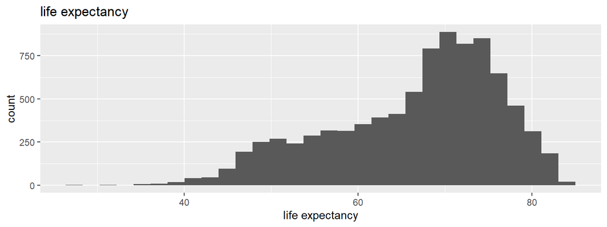

# In Base R, Every Graph is a Different Command

- `hist()`
- `plot(density())`
- not sure if you can do this in Base R

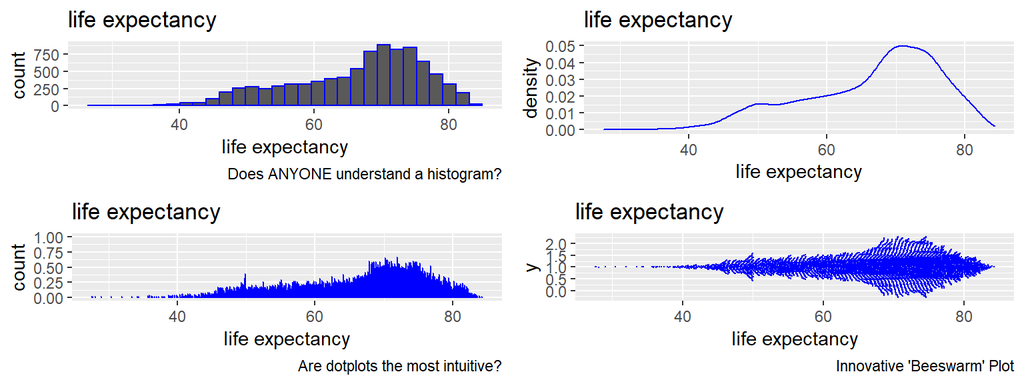

# Overlaying Graph Types Can Be Difficult

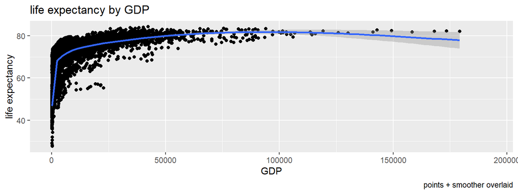

# Labelling and Legends Can Be Difficult

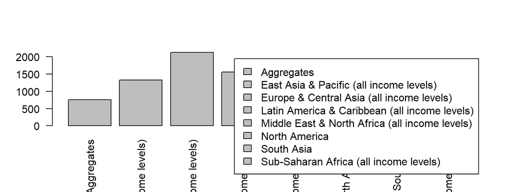

```r
barplot(table(mydata$region), # you have to TABULATE region
        las = 2, # try to fix the label angle
        names.arg = row.names(table(mydata$region)),
        legend = TRUE) # turn on legending
```

```r
# names for legend are row.names of table of regions
```

# A Grammar of Graphics (Wilkinson)

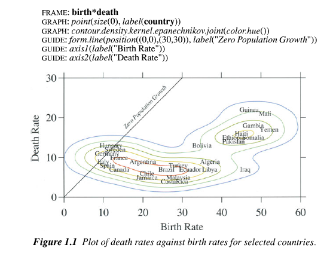

# A Grammar of Graphics (Revision)

> “Revision means, literally, to see again. For graphics, it implies that we want to change, query, and explore without having to go through all the work of specifying and creating a new graphic. By carefully separating the process of graph creation into hierarchical components, we enable a flexible environment that offers new views without recalculating every step in the system. And we can link controllers to any component or property in the system to provide direct manipulation of data, variables, frames, or rendering. If more than one graphic depends on the same sub-component, then they are linked as well.”"

# A Grammar of Graphics (Revision 2)

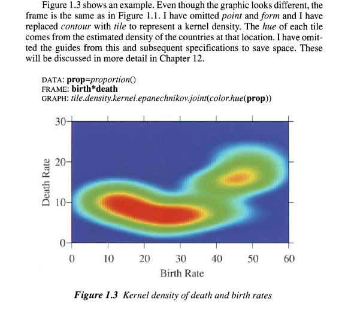

# A Design Tree

We *might* more easily think about revision, if we think about a *design tree*.

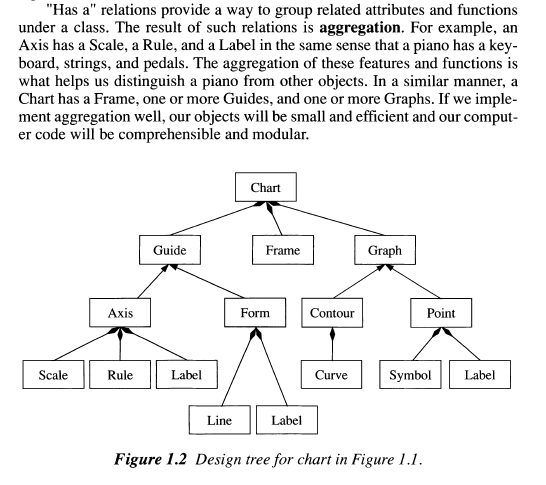

> “From a small seed, a mighty trunk may grow.” – Aeschylus

# A Grammar of Graphics (Wickham)

1. An *aesthetic*: What are we graphing?
2. *Geometries*: How are we graphing those things?
3. *Options*, *titles*, *labels*, etc.

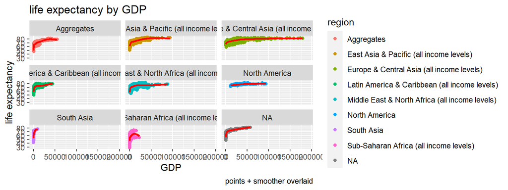

What *grammatical statements* have I made here?

# What is a Dimension?

A *dimension* is an element (vector, variable) of data.

| country | year | GDP | Gini | life_expectancy |
| --- | --- | --- | --- | --- |
| United Arab Emirates | 1986 | 23056 | NA | 70.52 |
| United Arab Emirates | 1988 | 21908 | NA | 71.19 |

> “But supposing we grasp the notion of multidimensional space and spaces are finite, people say, ‘Why should I care about that?’ … And these are fair questions, but my feeling is that it changes the world in such a fundamental way. We cannot begin to comprehend the consequences of living in a world after we know certain things about it.”

> – Janna Levin

# What is a Dimension (2)?

- Dimensions can be axes.

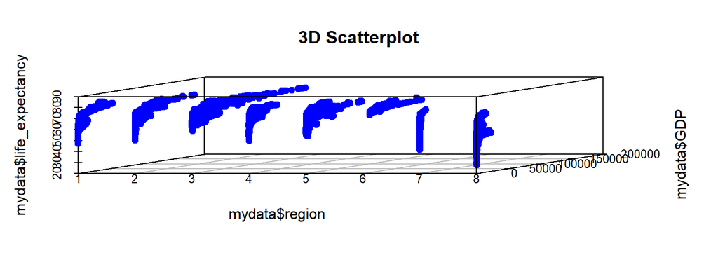

- But as we move along, we will also see that dimensions can be *colors*, *shapes*, *linetypes*, *transparency*, and *facets*.

# How Many Dimensions? (The Minimalist (‘Tufte’) View)

- My interpretation of Tufte tries to balance graphical minimalism and informative text.
- Use textbox for *key takeaway*?
- Using `theme_tufte()` from `library(ggthemes)`.

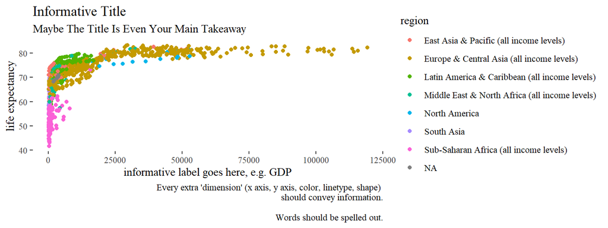

# We May, Or May Not, Want Chartjunk

It’s an Open Question

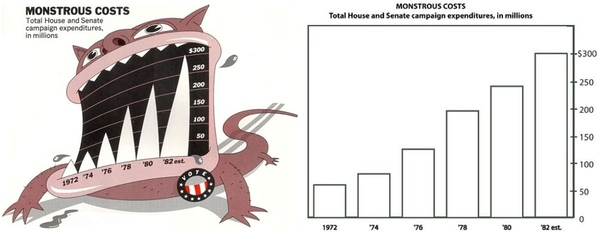

# How Many Dimensions? (A View Based On Accessibility)

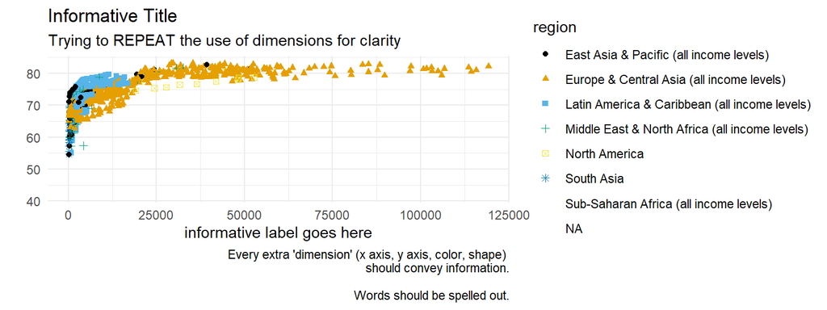

# Facets (“Small Multiples”)

- A better way of displaying categorical variables with a small number of variables.
- May make the presentation more accessible.

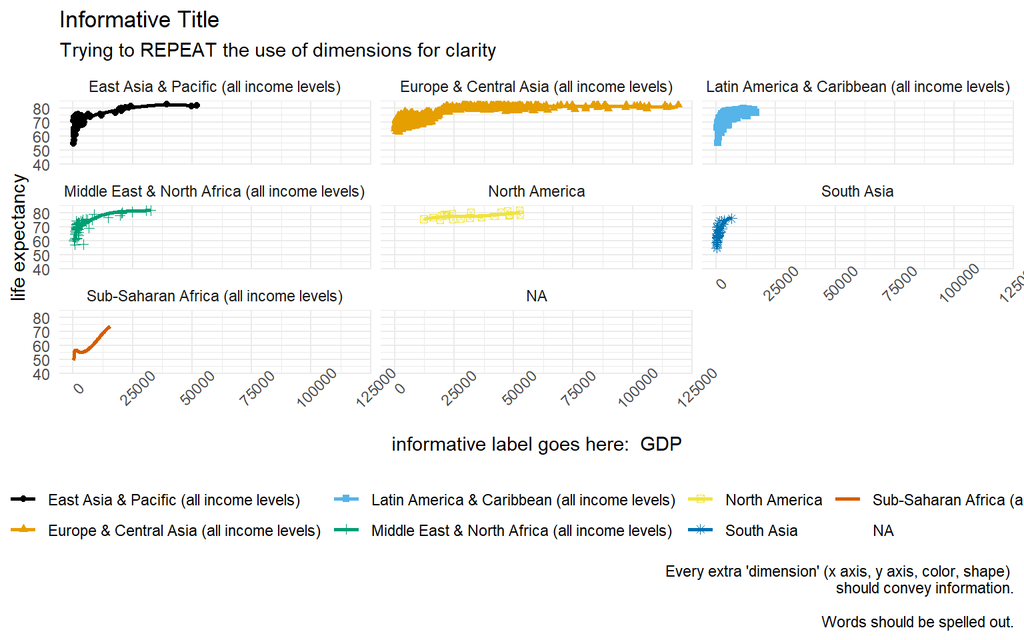

# The Essential **Grammar of Graphics** Of ggplot2 Is Simple.

There are 3 essential elements to any ggplot call:

1. An *aesthetic* that tells ggplot which variables are being mapped to the *x axis*, *y axis*, (and often other attributes of the graph, such as the *color fill*). Intuitively, the aesthetic can be thought of as *what you are graphing*.
2. A *geom* or *geometry* that tells ggplot about the basic structure of the graph. Intuitively, the geom can be thought of as *how you are graphing it*.
3. Other options, such as a *graph title*, *axis labels* and *overall theme* for the graph.

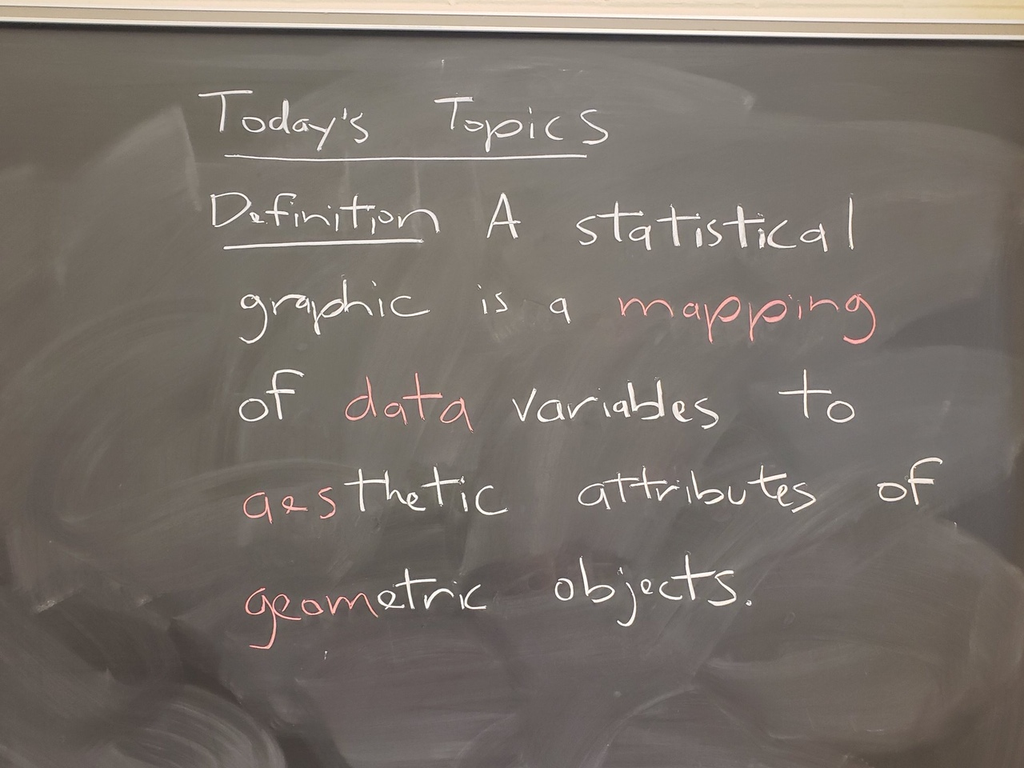

# So, as a quick and simple example …

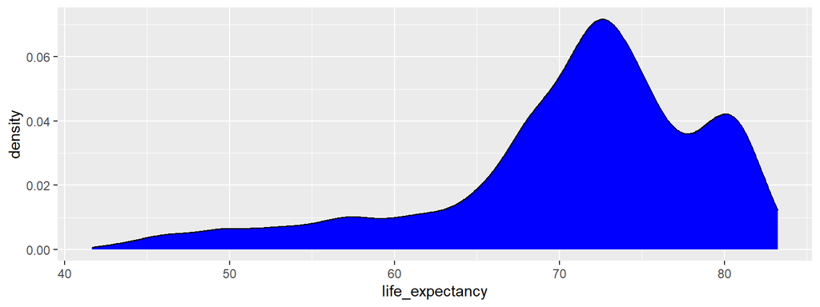

```r
ggplot(mydata, # the data that I am using
       aes(x = life_expectancy)) + # aesthetic: what I am graphing
  geom_density(fill = "blue") # geom: how I am graphing it
```

# More “layers” of information …

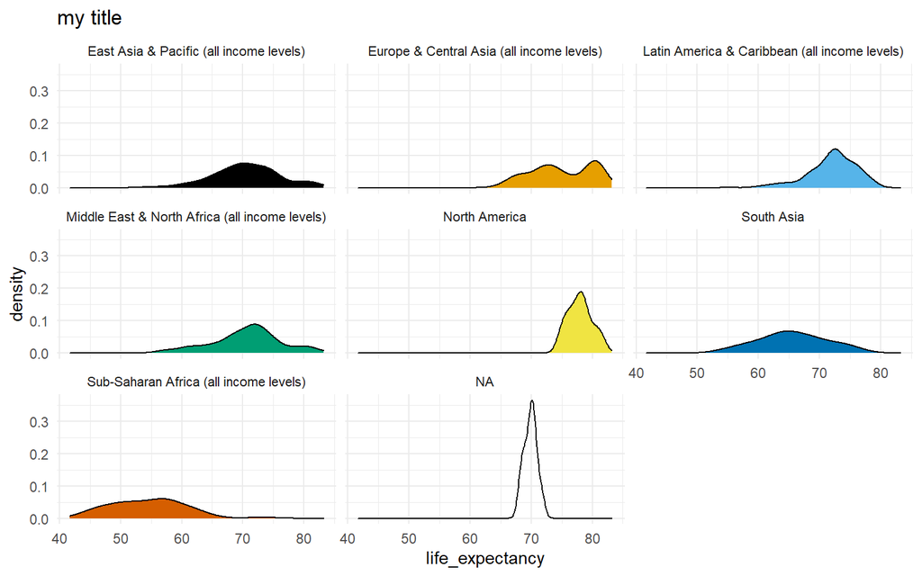

```r
library(ggthemes)

ggplot(mydata, # the data that I am using
       aes(x = life_expectancy,
           fill = region)) + # aesthetic: what I am graphing
  geom_density() + # geom: how I am graphing it
  labs(title = "my title") +
  theme_minimal() +
  theme(legend.position = "none",
        strip.text = element_text(size = rel(.75))) + # text size
  scale_fill_colorblind() +
  facet_wrap(~region)
```

# Where do the colors come from?

> “The default colour scheme, scale_colour_hue picks evenly spaced hues around the hcl colour wheel”
- Wickham, *ggplot2 book*, p. 106

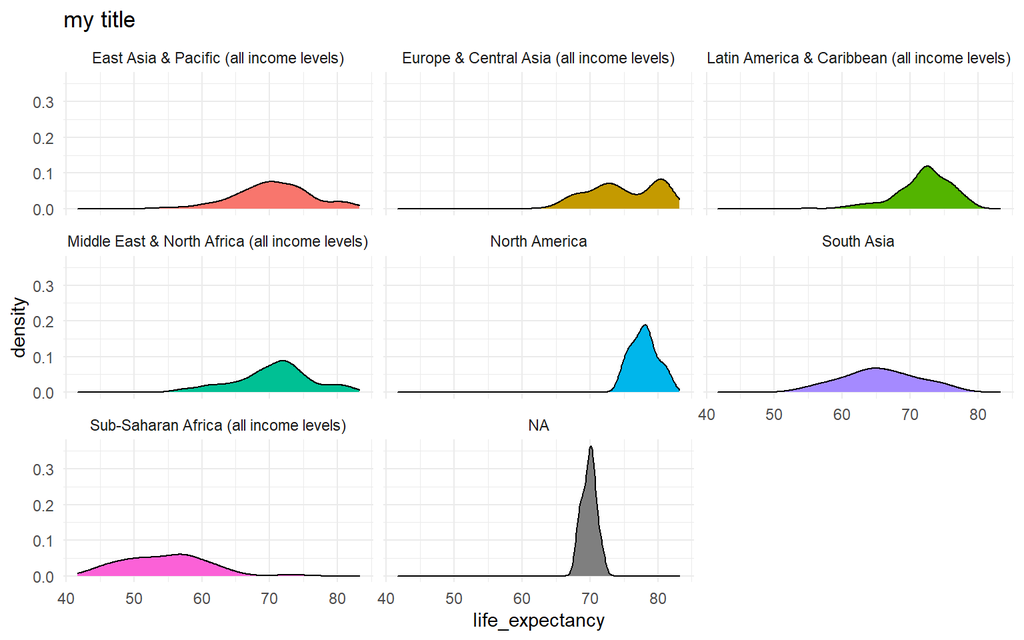

```r
ggplot(mydata, # the data that I am using
       aes(x = life_expectancy,
           fill = region)) + # aesthetic: what I am graphing
  geom_density() + # geom: how I am graphing it
  labs(title = "my title") +
  theme_minimal() +
  theme(legend.position = "none") +
  facet_wrap(~region)
```

# Questions?

[^1]: See *Introduction to R* for more discussion of factor variable syntax.